# Estudo R for Data Science - Cap 2

## **Aesthetic Mapping**

Aesthetic é uma propriedade visual do objeto no plot, podemo adicionar funções que destacam o tamanho, shape ou cor.

Utilizando **aesthetic** `color` mapeando a classe o `ggplot` automaticamente cria uma legenda e atribuiu uma cor específica para cada tipo de classe, processo chamado de **scaling**

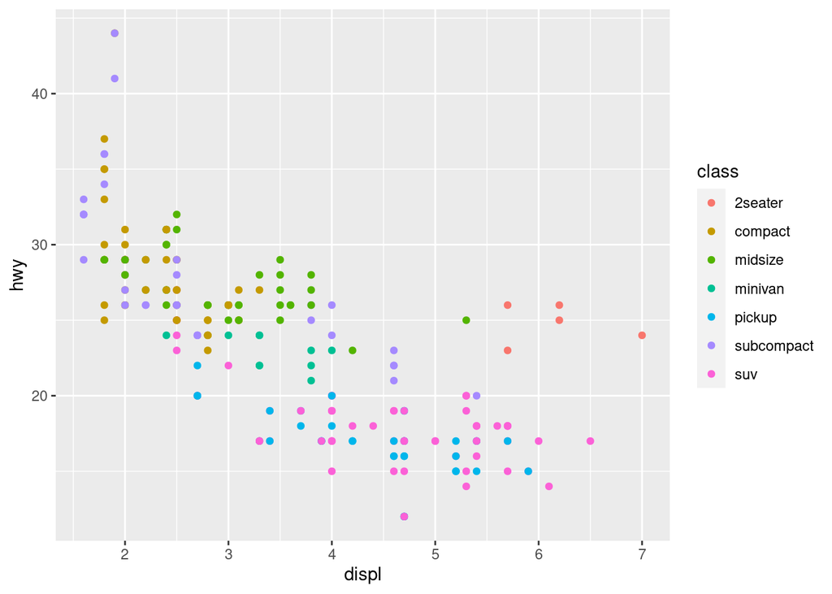

```r
ggplot(data = mpg)+
  geom_point(mapping = aes(x= displ, y= hwy, color=class))
```

Além de `color` podemos utilizar `size`, outras opções são `alpha` e `shape` .

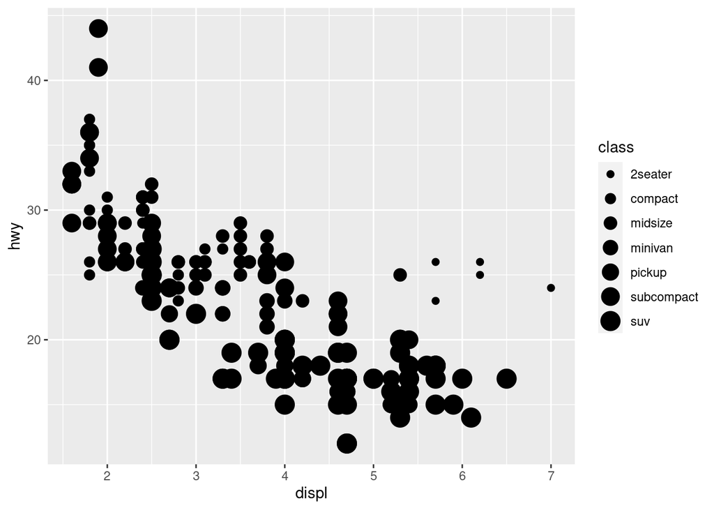

```r
ggplot(data = mpg)+
  geom_point(mapping = aes(x= displ, y= hwy, size=class))
```

#### Exercícios 3.3.1:

**1. What’s gone wrong with this code? Why are the points not blue?**

**Resposta** : `blue` é intepretado como uma variável por isso o ggplot não identificou a cor, para modificar a cor do gráfico pode-se adicionar color fora do `aes`

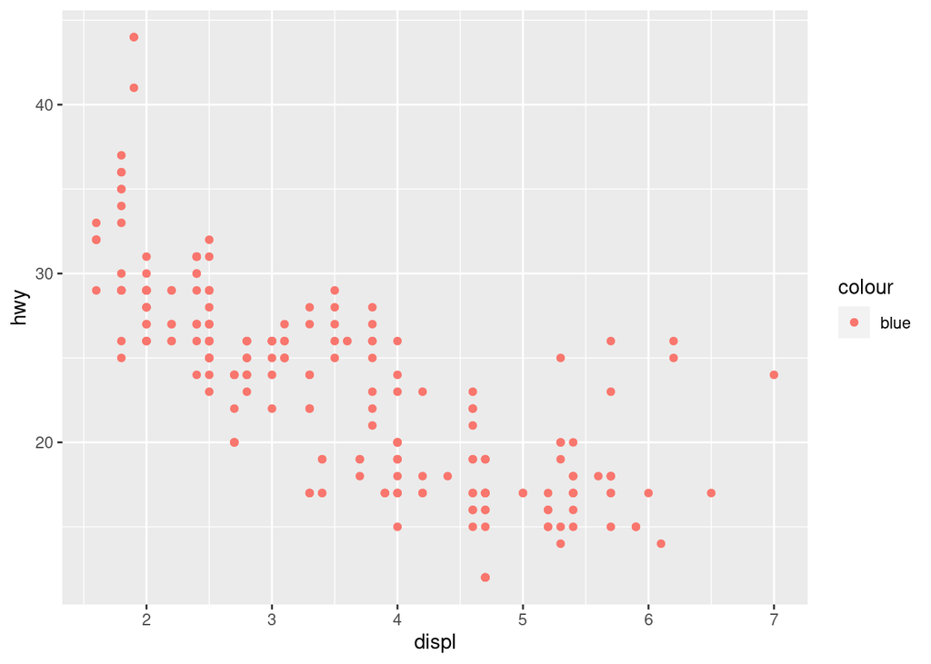

```r
ggplot(data = mpg) +
  geom_point(mapping = aes(x = displ, y = hwy, color = "blue"))
```

Fix: *Incluindo a cor fora do aes*

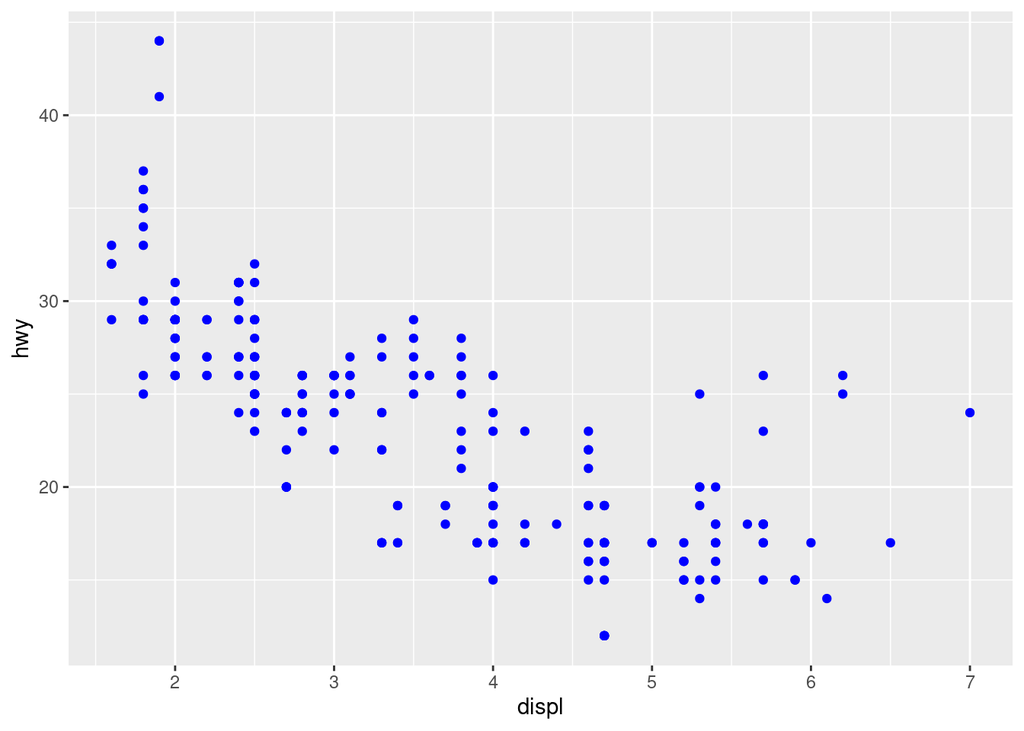

```r
ggplot(data = mpg) +
  geom_point(mapping = aes(x = displ, y = hwy), color = "blue")
```

**2. Which variables in mpg are categorical? Which variables are continuous? (Hint: type ?mpg to read the documentation for the dataset). How can you see this information when you run mpg?**

```r
glimpse(mpg)
```

```
## Rows: 234
## Columns: 11
## $ manufacturer <chr> "audi", "audi", "audi", "audi", "audi", "audi", "audi", …
## $ model        <chr> "a4", "a4", "a4", "a4", "a4", "a4", "a4", "a4 quattro", …
## $ displ        <dbl> 1.8, 1.8, 2.0, 2.0, 2.8, 2.8, 3.1, 1.8, 1.8, 2.0, 2.0, 2…
## $ year         <int> 1999, 1999, 2008, 2008, 1999, 1999, 2008, 1999, 1999, 20…
## $ cyl          <int> 4, 4, 4, 4, 6, 6, 6, 4, 4, 4, 4, 6, 6, 6, 6, 6, 6, 8, 8,…
## $ trans        <chr> "auto(l5)", "manual(m5)", "manual(m6)", "auto(av)", "aut…
## $ drv          <chr> "f", "f", "f", "f", "f", "f", "f", "4", "4", "4", "4", "…
## $ cty          <int> 18, 21, 20, 21, 16, 18, 18, 18, 16, 20, 19, 15, 17, 17, …
## $ hwy          <int> 29, 29, 31, 30, 26, 26, 27, 26, 25, 28, 27, 25, 25, 25, …
## $ fl           <chr> "p", "p", "p", "p", "p", "p", "p", "p", "p", "p", "p", "…
## $ class        <chr> "compact", "compact", "compact", "compact", "compact", "…
```

**Categórica :** manufacturer, model, trans, drv, fl, class

**Contínua :** displ, year, cyl, cty, hwy

**3. Map a continuous variable to color, size, and shape. How do these aesthetics behave differently for categorical vs. continuous variables?**

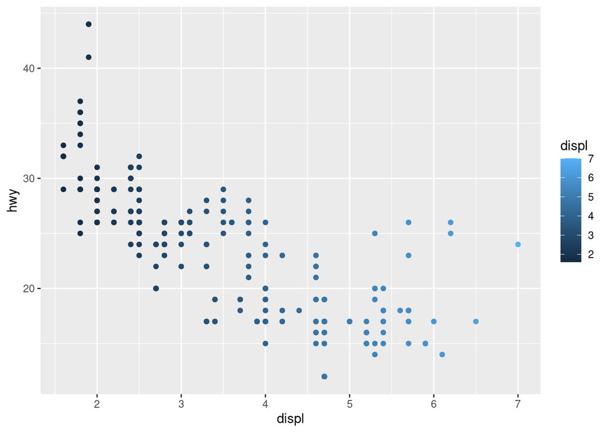

```r
ggplot(data = mpg) +
  geom_point(mapping = aes(x = displ,  y = hwy, color = displ))
```

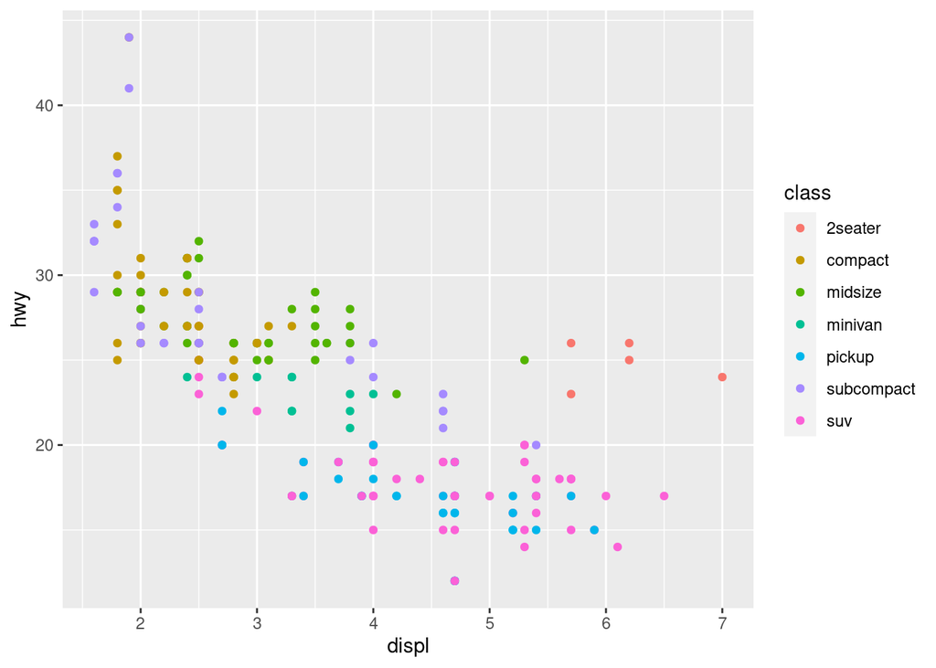

```r
ggplot(data = mpg) +
  geom_point(mapping = aes(x = displ,  y = hwy, color = class))
```

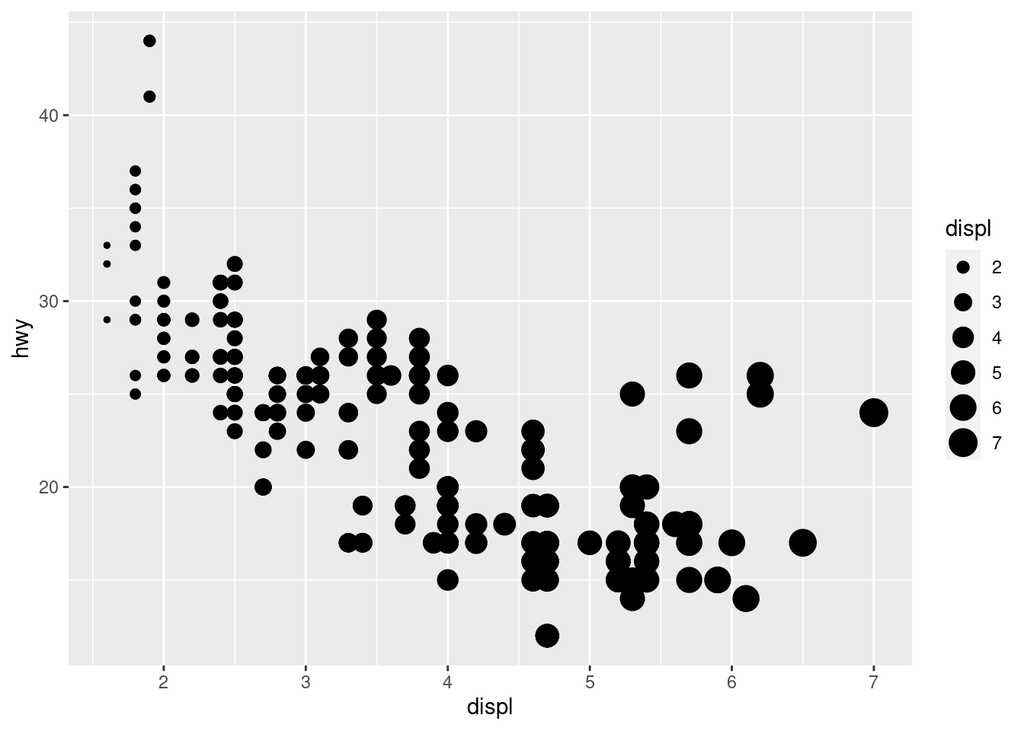

```r
ggplot(data = mpg) +
  geom_point(mapping = aes(x = displ,  y = hwy, size = displ))
```

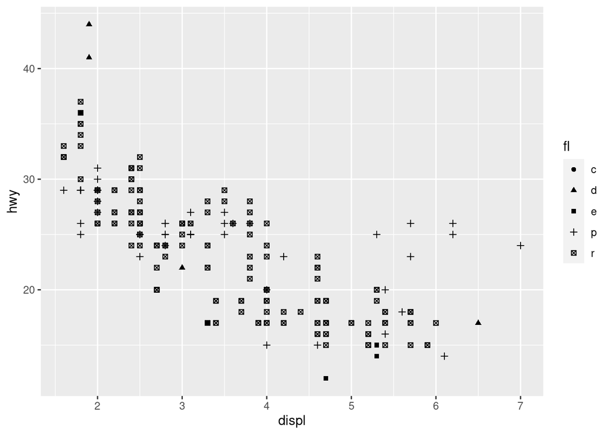

```r
ggplot(data = mpg) +
  geom_point(mapping = aes(x = displ,  y = hwy, shape = fl))
```

**4. What happens if you map the same variable to multiple aesthetics?**

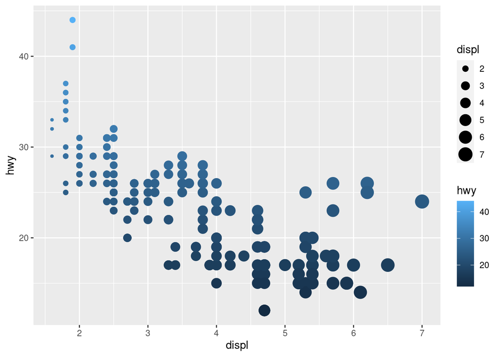

```r
ggplot(mpg, aes(x = displ, y = hwy, colour = hwy, size = displ)) +
  geom_point()
```

**5. What does the stroke aesthetic do? What shapes does it work with? (Hint: use ?geom_point)**

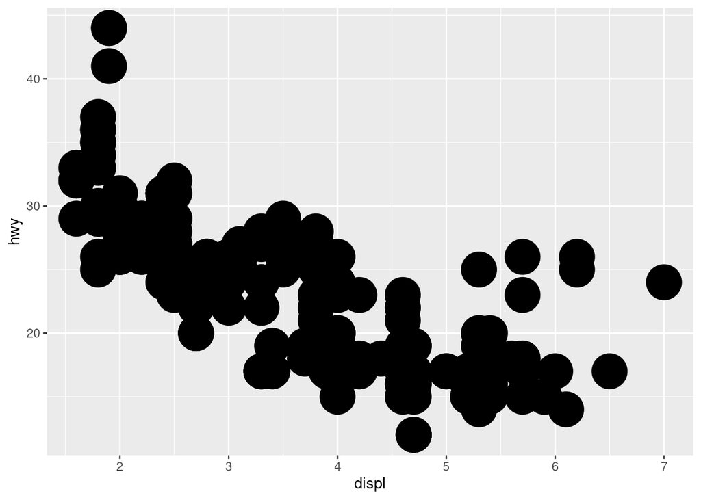

```r
ggplot(data = mpg) +
  geom_point(mapping = aes(x = displ,  y = hwy, stroke =8 ))
```

**6. What happens if you map an aesthetic to something other than a variable name, like aes(colour = displ < 5)? Note, you’ll also need to specify x and y.**

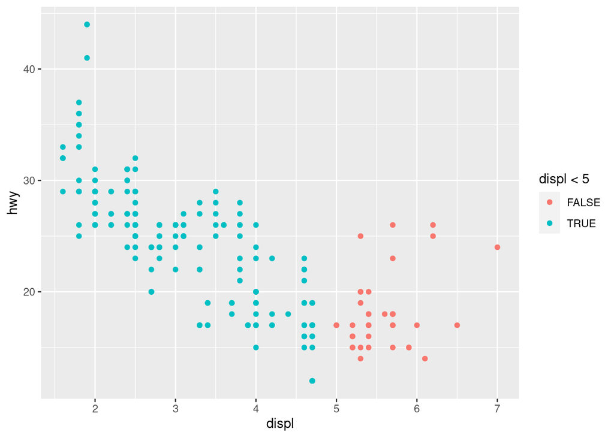

```r
ggplot(data = mpg) +
  geom_point(mapping = aes(x = displ,  y = hwy, color= displ < 5))
```

## Facet

O autor destaca que outra forma de observar variáveis categóricas é dividir o gráfico em `facet`, ou seja, criar subplots para cada tipo da variável. A função utilizada é a `facet_wrap()`.

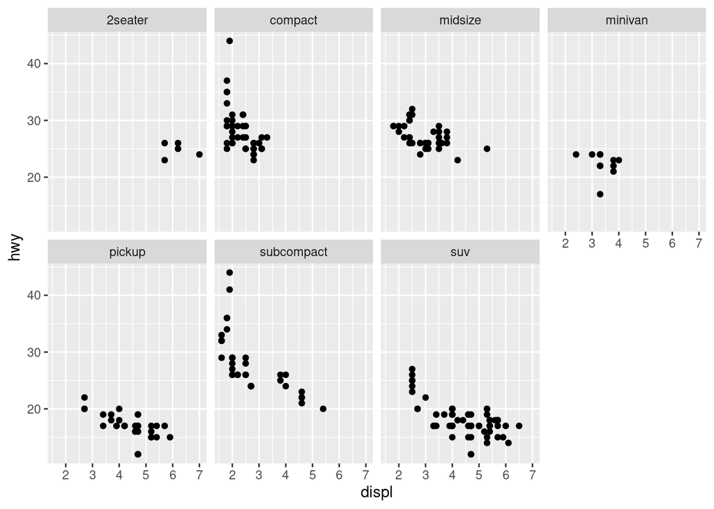

```r
ggplot(data = mpg, aes(x=displ, y=hwy))+
  geom_point() +
  facet_wrap(~ class, nrow = 2)
```

Para combinar duas variáveis com `facet` utilizamos o `facet_grid()`

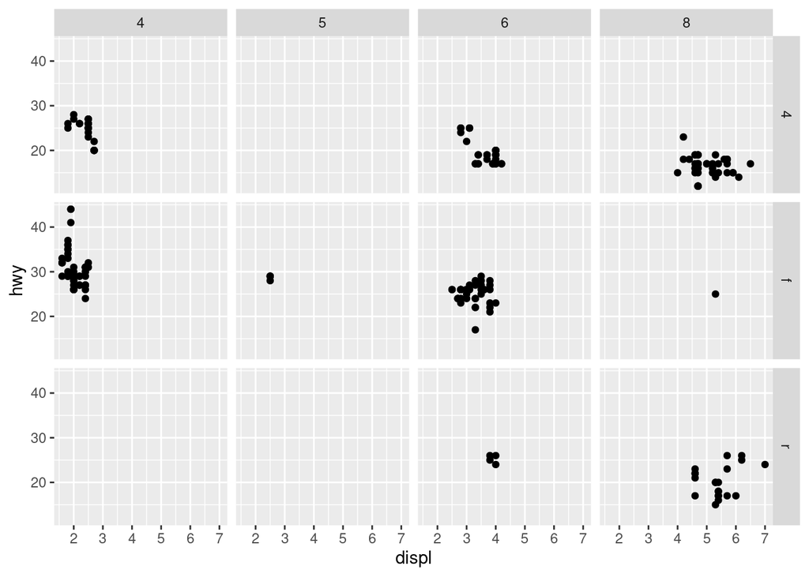

```r
ggplot(data = mpg)+
  geom_point(mapping = aes(x = displ , y = hwy)) +
  facet_grid(drv ~ cyl)
```

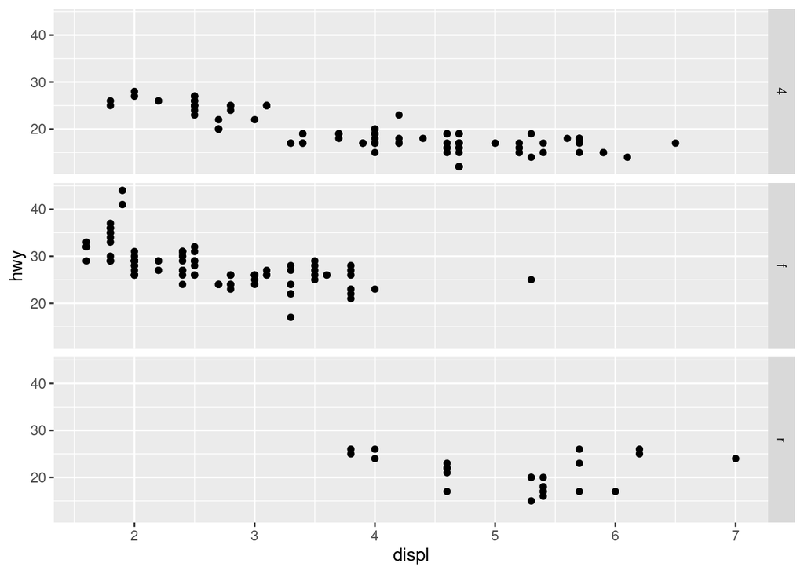

```r
ggplot(data = mpg)+
  geom_point(mapping = aes(x = displ , y = hwy)) +
  facet_grid(drv ~ .)
```

#### Exercícios 3.5.1:

**1. What happens if you facet on a continuous variable?**

**Resposta :** Na minha opinião , não é gráfico muito últil ter uma variável continua no facet, pois ele irá dividir o gráfico em muitas camadas.

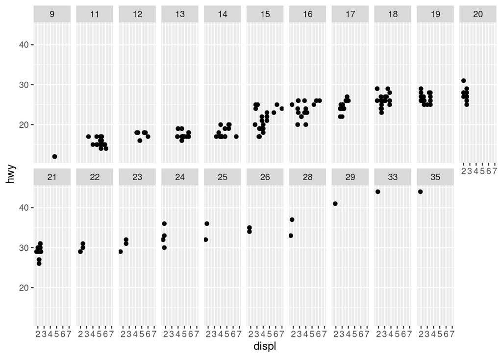

```r
ggplot(data = mpg, aes(x=displ, y=hwy))+
  geom_point() +
  facet_wrap(~ cty, nrow = 2)
```

```r
#glimpse(mpg)
```

**2. What do the empty cells in plot with `facet_grid(drv ~ cyl)` mean? How do they relate to this plot?**

**Resposta :**

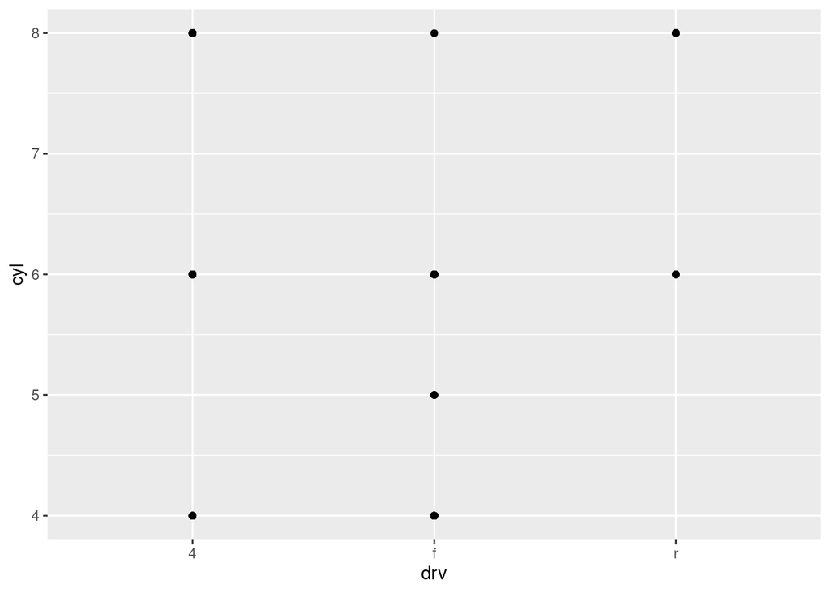

```r
ggplot(data = mpg) +
  geom_point(mapping = aes(x = drv, y = cyl))
```

**3. What plots does the following code make? What does `.` do?**

**Resposta :** Define em qual axis e qual variável você quer observar.

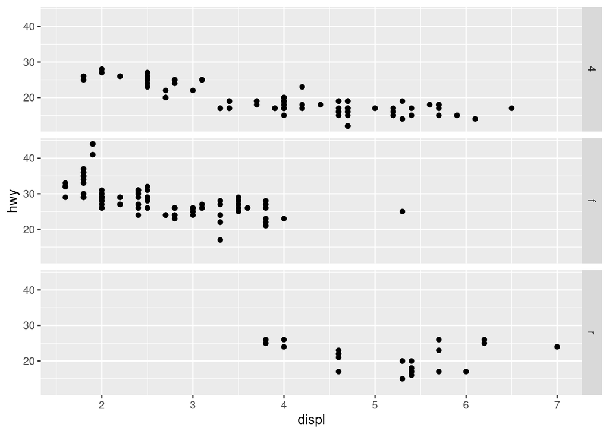

```r
ggplot(data = mpg) +
  geom_point(mapping = aes(x = displ, y = hwy)) +
  facet_grid(drv ~ .)
```

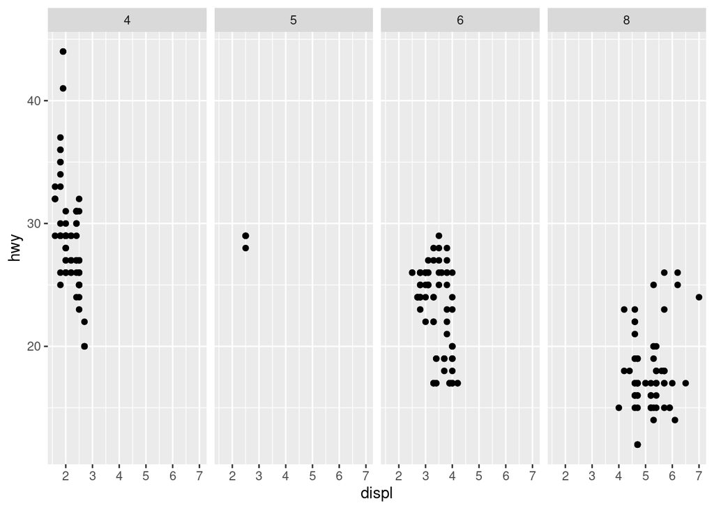

```r
ggplot(data = mpg) +
  geom_point(mapping = aes(x = displ, y = hwy)) +
  facet_grid(. ~ cyl)
```

**4. Take the first faceted plot in this section:**

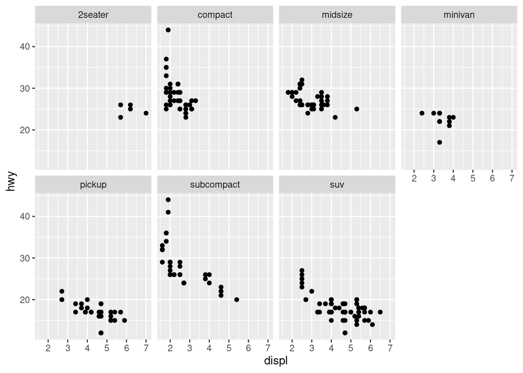

```r
ggplot(data = mpg) +
  geom_point(mapping = aes(x = displ, y = hwy)) +
  facet_wrap(~ class, nrow = 2)
```

**What are the advantages to using faceting instead of the colour aesthetic? What are the disadvantages? How might the balance change if you had a larger dataset?**

**Resposta :** A vantagem de usar facet em relação a aes é porque você pode observar cada classe de forma isolada, já com color as cores se misturam e não fica claro cada grupo, outro detalhe é se tivermos muitos grupos/classes complica mais a identificação de cada grupo. Casos de datasets muito grandes ou com diversas classes devemos podemos tentar filtrar por grupos, ou então teremos um facet com muitas camadas, e caso utilize colour não terá cores para todos os tipos.

**5. Read `?facet_wrap`. What does nrow do? What does ncol do? What other options control the layout of the individual panels? Why doesn’t facet_grid() have nrow and ncol arguments?**

**Resposta :** ncol e nrow especifica o número de colunas ou linhas que irá dividir seu subplot, outras opções para controlar o layout são : scales, shrink.

**6. When using facet_grid() you should usually put the variable with more unique levels in the columns. Why?**

**Resposta :** Para não ter diversas subdivisoes no plot

## Geometric Objects

**geoms** são normalmente conhecidos por tipos de gráficos como bar chart, line chart, , boxplot, scatterplot, etc. Cada um desses tipos de gráficos tem seu proprio `geom` .

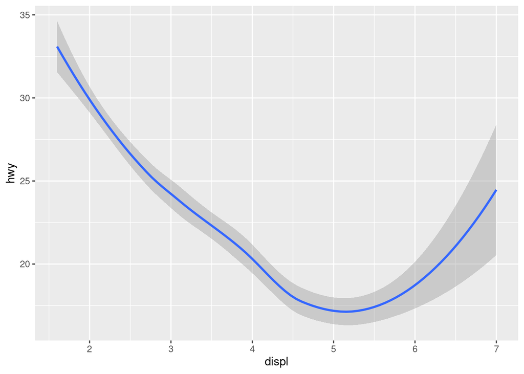

```r
ggplot(data = mpg) +
  geom_smooth(mapping = aes(x = displ, y = hwy))
```

Adicionando `linetype` , com isso o ggplot irá separar os carros em 3 categorias de `drv` :

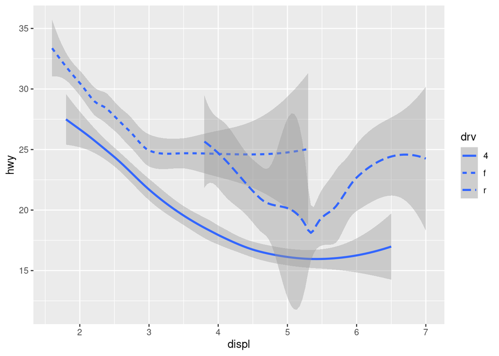

```r
ggplot(data = mpg) +
  geom_smooth(mapping = aes(x = displ, y = hwy , linetype= drv))
```

Podemos adicionar uma camada de `geom` em cima da outra, combinado o gráfico de linhas com o scatterplot

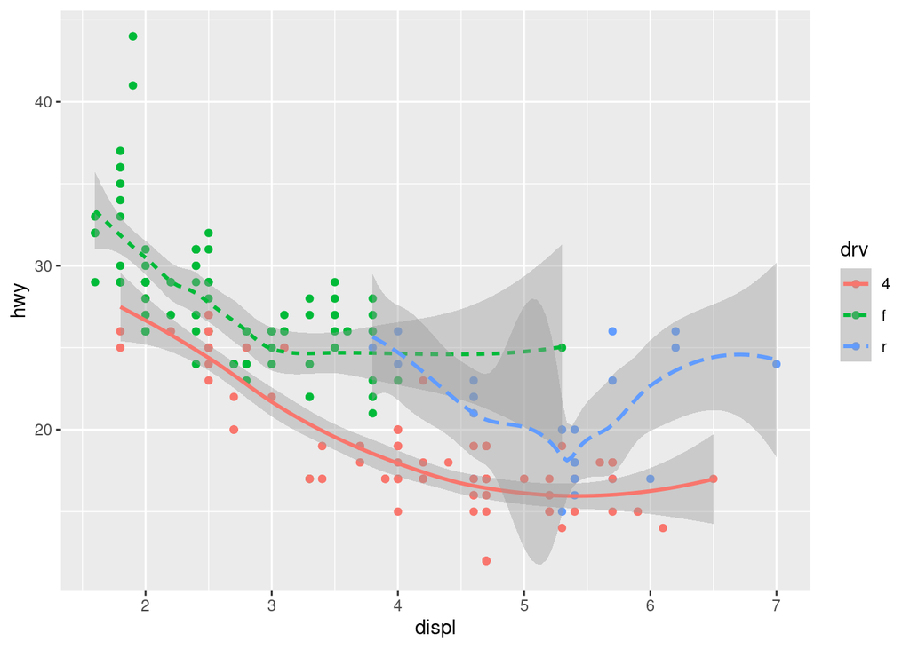

```r
ggplot(data = mpg) +
  geom_point(mapping = aes(x = displ, y = hwy, color = drv)) +
  geom_smooth(mapping = aes(x = displ, y = hwy , linetype= drv, color = drv))
```

Uma das opções do `geom_smooth` é utilizar as opções de `group` e `color` para plotar variáveis categóricas :

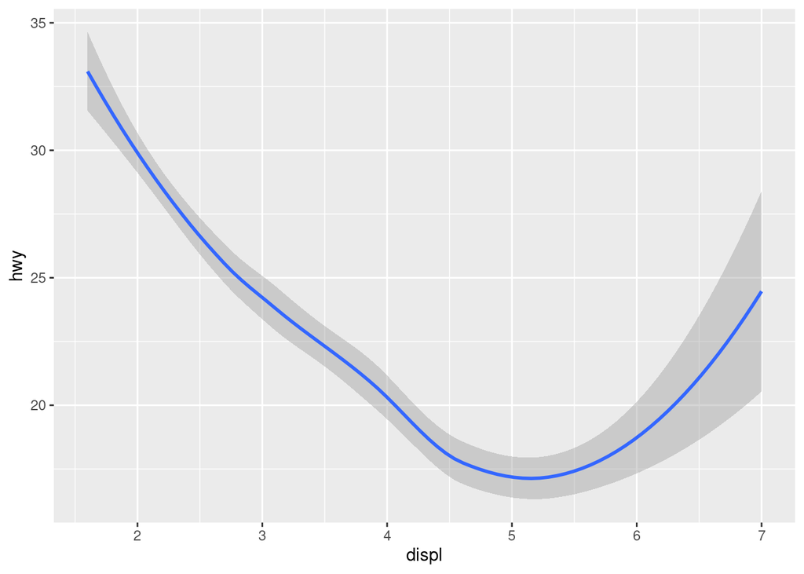

```r
ggplot(data = mpg) +
  geom_smooth(mapping = aes(x = displ, y = hwy))
```

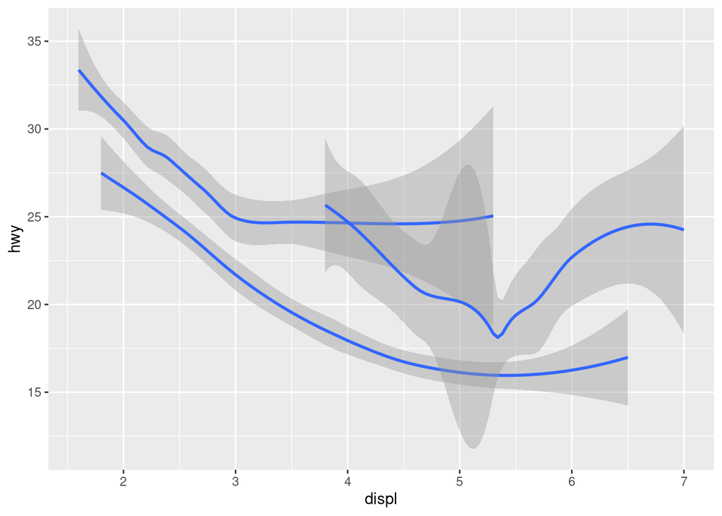

```r
ggplot(data = mpg) +
  geom_smooth(mapping = aes(x = displ, y = hwy, group = drv))
```

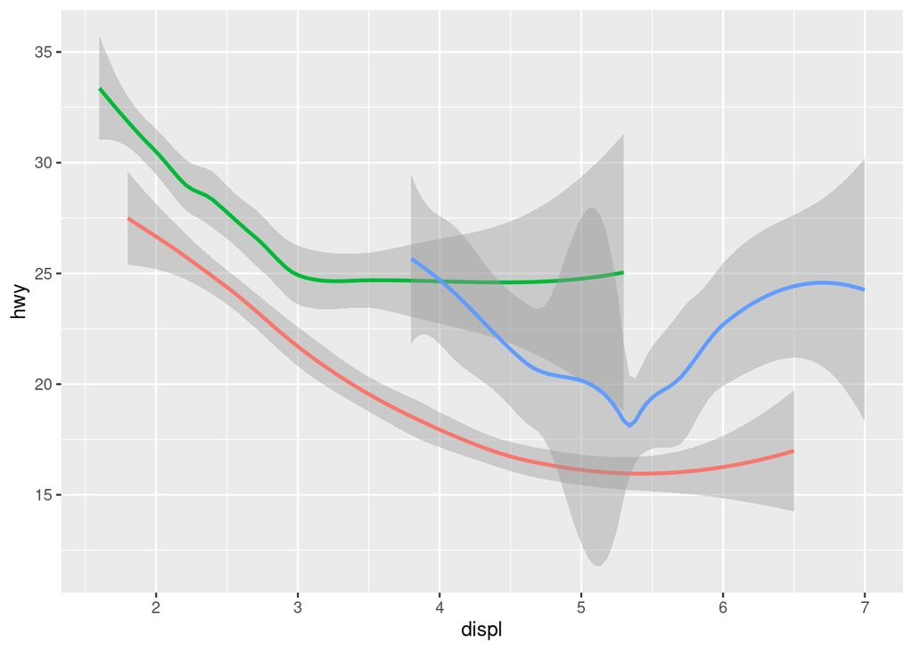

```r
ggplot(data = mpg) +
  geom_smooth(
    mapping = aes(x = displ, y = hwy, color = drv),
    show.legend = FALSE
  )
```

Para evitar que se duplique informação no gráfico adicionando geoms podemos tratar o `mappting` na parte **global** do ggplot

```r
ggplot(data = mpg, mapping = aes(x = displ, y = hwy)) +
  geom_point() +
  geom_smooth()
```

[output not shown]

Sobrescrevendo o mapping, neste caso o color para variável class será aplicado somente a camada de scatterplo:

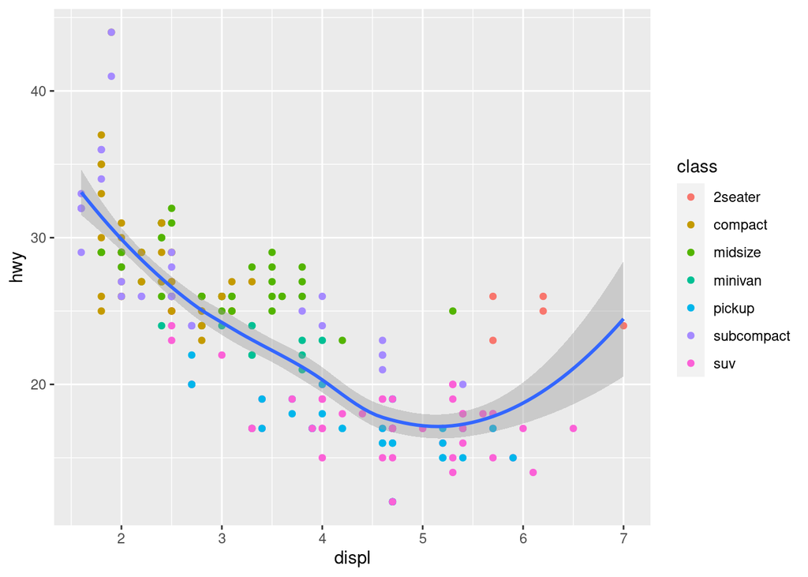

```r
ggplot(data = mpg, mapping = aes(x = displ, y = hwy)) +
  geom_point(mapping = aes(color = class)) +
  geom_smooth()
```

Filtrando os dados para alguma camada de plot :

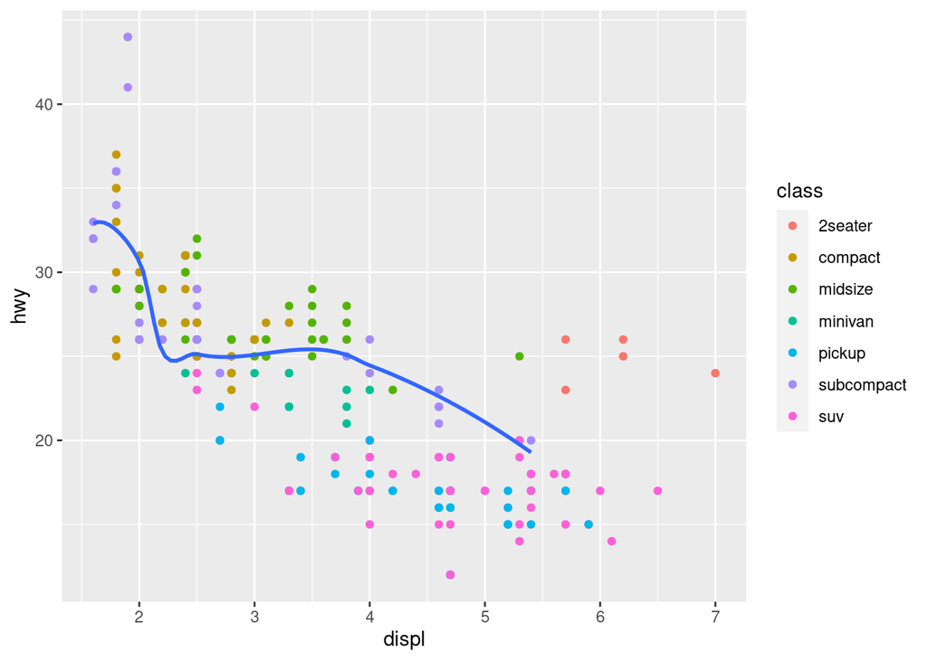

```r
ggplot(data = mpg, mapping = aes(x = displ, y = hwy))+
  geom_point(mapping = aes(color = class))+
  geom_smooth(data = filter(mpg, class == 'subcompact'), se = FALSE)
```